# R 객체- Vector

연규필

#### 학습목표: R에서 벡터(veocor) 객체에 대하여 이해하고 핸들링하는 명령어를 익힌다.

# 1 . 스칼라(Scalar)

- 단일 차원의 값을 의미하며 길이가 1인 벡터(즉, 원소가 하나인 벡터)로 볼 수 있음.

```r
# 숫자 스칼라
a = 3
b = 4
a+b
```

```
## [1] 7
```

```r
# 문자열 스칼라
text =  'Hello'
text
```

```
## [1] "Hello"
```

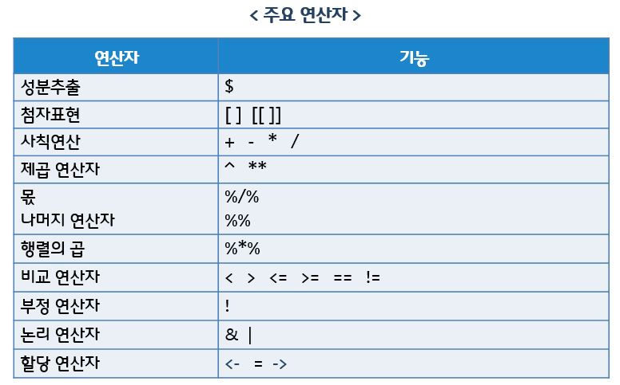

주요 연산자

```r
5*2
```

```
## [1] 10
```

```r
5/2
```

```
## [1] 2.5
```

```r
5^2
```

```
## [1] 25
```

```r
5%/%2
```

```
## [1] 2
```

```r
5%%2
```

```
## [1] 1
```

```r
5<2
```

```
## [1] FALSE
```

```r
5>2
```

```
## [1] TRUE
```

```r
5==2
```

```
## [1] FALSE
```

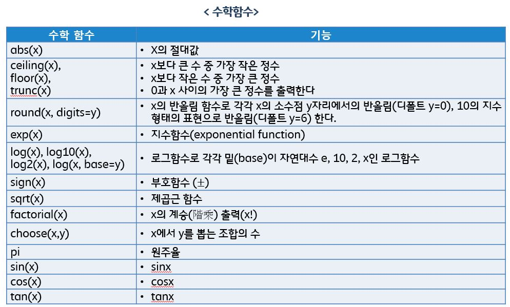

수학함수

```r
pi
```

```
## [1] 3.141593
```

```r
sqrt(5)
```

```
## [1] 2.236068
```

```r
log(10)
```

```
## [1] 2.302585
```

```r
log10(10)
```

```
## [1] 1
```

```r
abs(-10)
```

```
## [1] 10
```

```r
factorial(5)
```

```
## [1] 120
```

```r
choose(5,2)
```

```
## [1] 10
```

```r
ceiling(-3.4)
```

```
## [1] -3
```

```r
floor(-3.4)
```

```
## [1] -4
```

```r
trunc(-3.4)
```

```
## [1] -3
```

```r
round(-3.42, digit=1)
```

```
## [1] -3.4
```

# 2 . R 숫자 벡터

## 2.1 숫자벡터 생성

### 2.1.1 c() 함수 이용

```r
m_score1 = c(98, 90, 86, 76, 78, 85, 88, 93, 82, 90)
m_score2 = c(87, 93, 96, 91, 87, 85, 92, 88, 94, 97)
score =c(m_score1,m_score2)
m_score1; m_score2; score
```

```
##  [1] 98 90 86 76 78 85 88 93 82 90
```

```
##  [1] 87 93 96 91 87 85 92 88 94 97
```

```
##  [1] 98 90 86 76 78 85 88 93 82 90 87 93 96 91 87 85 92 88 94 97
```

### 2.1.2 seq, n:m, rep, rev

```r
seq(1,10)
```

```
##  [1]  1  2  3  4  5  6  7  8  9 10
```

```r
x.2=1:10
x.2
```

```
##  [1]  1  2  3  4  5  6  7  8  9 10
```

```r
seq(from=1, to=10, by=2)
```

```
## [1] 1 3 5 7 9
```

```r
seq(from=1, to=10, length=4)
```

```
## [1]  1  4  7 10
```

```r
rep(1,5)
```

```
## [1] 1 1 1 1 1
```

```r
rep(1:3, times=5)
```

```
##  [1] 1 2 3 1 2 3 1 2 3 1 2 3 1 2 3
```

```r
rep(1:3, each=2, times=3)
```

```
##  [1] 1 1 2 2 3 3 1 1 2 2 3 3 1 1 2 2 3 3
```

```r
rep(c(1,3,5),times=c(1,2,3))
```

```
## [1] 1 3 3 5 5 5
```

```r
rev(1:10)
```

```
##  [1] 10  9  8  7  6  5  4  3  2  1
```

```r
10:1
```

```
##  [1] 10  9  8  7  6  5  4  3  2  1
```

## 2.2 숫자벡터의 연산

```r
(x=c(1,2,3));(y=4:6)
```

```
## [1] 1 2 3
```

```
## [1] 4 5 6
```

```r
x+y; x-y; x*y; x/y
```

```
## [1] 5 7 9
```

```
## [1] -3 -3 -3
```

```
## [1]  4 10 18
```

```
## [1] 0.25 0.40 0.50
```

```r
exp(x); log(x); sqrt(x)
```

```
## [1]  2.718282  7.389056 20.085537
```

```
## [1] 0.0000000 0.6931472 1.0986123
```

```
## [1] 1.000000 1.414214 1.732051
```

```r
x<-c(1,2,3,4,5);x+1
```

```
## [1] 2 3 4 5 6
```

```r
identical(c(1,2,3),c(1,2,3))
```

```
## [1] TRUE
```

```r
identical(c(1,2,3),c(1,2,100))
```

```
## [1] FALSE
```

```r
c(1,2,3)==c(1,2,100)
```

```
## [1]  TRUE  TRUE FALSE
```

```r
c(1,2,3)!=c(1,2,100)
```

```
## [1] FALSE FALSE  TRUE
```

## 2.3 기초통계 함수 적용

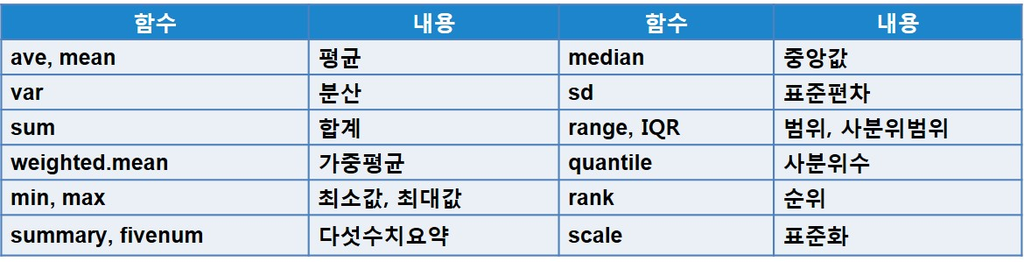

기초통계함수

```r
stat = c(87,85,86,96,78,83,89,95,92,68)
sum(stat); mean(stat); median(stat); max(stat); min(stat)
```

```
## [1] 859
```

```
## [1] 85.9
```

```
## [1] 86.5
```

```
## [1] 96
```

```
## [1] 68
```

```r
quantile(stat); quantile(stat,probs = c(0.01, 0.05, 0.95, 0.99))
```

```
##    0%   25%   50%   75%  100%
## 68.00 83.50 86.50 91.25 96.00
```

```
##    1%    5%   95%   99%
## 68.90 72.50 95.55 95.91
```

```r
range(stat);IQR(stat); var(stat); sd(stat)
```

```
## [1] 68 96
```

```
## [1] 7.75
```

```
## [1] 69.43333
```

```
## [1] 8.332667
```

```r
summary(stat)
```

```
##    Min. 1st Qu.  Median    Mean 3rd Qu.    Max.
##   68.00   83.50   86.50   85.90   91.25   96.00
```

## 2.4 벡터 인덱싱

- 벡터의 데이터를 접근하는 데에는 색인을 사용하는 방법이 있음
- 대괄호 []를 사용함
- 벡터의 각 엘리먼트에 이름이 부여되어 있다면 이름을 사용할 수 있음
- 벡터에서 특정 요소를 제외한 나머지 데이터를 가져오거나 동시에 여러 셀의 데이터에 접근이 가능함

```r
x=c(58,65,70,72,77,80,77,91,94,100)
x[1];x[1:3]; x[-c(1,2,3)]
```

```
## [1] 58
```

```
## [1] 58 65 70
```

```
## [1]  72  77  80  77  91  94 100
```

## 2.5 벡터의 정렬

```r
(stat = c(87,85,86,96,78,83,89,95,92,68))
```

```
##  [1] 87 85 86 96 78 83 89 95 92 68
```

```r
rank(stat); order(stat)
```

```
##  [1]  6  4  5 10  2  3  7  9  8  1
```

```
##  [1] 10  5  6  2  3  1  7  9  8  4
```

- rank는 각 엘리먼트 값의 순위를 나타냄(가장 작으면 1의 값을 가짐)
- order는 해당 rank 값을 갖는 엘리먼트의 위치를 나타냄  
  즉, order(stat)의 첫번째 값은 stat에서 가장 작은 엘리먼트의 위치를 나타내고, 두번째 값은 두번째로 작은 엘리먼트의 위치를 나타냄.

```r
sort(stat); sort(stat, decreasing=T)
```

```
##  [1] 68 78 83 85 86 87 89 92 95 96
```

```
##  [1] 96 95 92 89 87 86 85 83 78 68
```

```r
stat[order(stat)]
```

```
##  [1] 68 78 83 85 86 87 89 92 95 96
```

- 위와같이 order를 이용하여 sorting을 할 수 있음(대괄호[ ]의 쓰임은 추후 설명)
- sort 함수는 벡터를 정렬하는데는 유용하나, 뒤에서 다룰 데이터프레임을 정렬하는 데는 불편함

# 3 . R 문자열 벡터

- 문자열로 이루어진 벡터를 말함

## 3.1 문자열 벡터의 생성

```r
(family.1=c("Ben","Yeong","Irene","Sam"))
```

```
## [1] "Ben"   "Yeong" "Irene" "Sam"
```

```r
(family.2=c("Tom","Baek","Alice","Poly"))
```

```
## [1] "Tom"   "Baek"  "Alice" "Poly"
```

```r
(family= c(family.1, family.2))
```

```
## [1] "Ben"   "Yeong" "Irene" "Sam"   "Tom"   "Baek"  "Alice" "Poly"
```

- 문자형과 숫자형을 섞어 저장하면 모두 문자형으로 인식

```r
c("Min",95,97,90)
```

```
## [1] "Min" "95"  "97"  "90"
```

## 3.2 문자열 벡터의 연산

```r
(c1 = "Yeon Kyupil"); nchar(c1);substr(c1, 1, 4)
```

```
## [1] "Yeon Kyupil"
```

```
## [1] 11
```

```
## [1] "Yeon"
```

```r
(c2 = "연규필"); nchar(c2);substr(c2, 2, 3)
```

```
## [1] "연규필"
```

```
## [1] 3
```

```
## [1] "규필"
```

```r
"a" %in% c("a","b","c")
```

```
## [1] TRUE
```

```r
"d" %in% c("a","b","c")
```

```
## [1] FALSE
```

```r
union(c("a","b","c"), c("a","d"))
```

```
## [1] "a" "b" "c" "d"
```

```r
intersect(c("a","b","c"), c("a","d"))
```

```
## [1] "a"
```

```r
setdiff(c("a","b","c"), c("a","d"))
```

```
## [1] "b" "c"
```

```r
setequal(c("a","b","c"), c("a","d"))
```

```
## [1] FALSE
```

```r
setequal(c("a","b","c"), c("a","b","c","d"))
```

```
## [1] FALSE
```

```r
setequal(c("a","b","c"), c("a","b","c","c"))
```

```
## [1] TRUE
```

- paste 함수의 이용

```r
date();paste("Today is", date())
```

```
## [1] "Mon Jun 10 09:41:54 2019"
```

```
## [1] "Today is Mon Jun 10 09:41:54 2019"
```

```r
paste("Name :", c1)
```

```
## [1] "Name : Yeon Kyupil"
```

```r
paste("1st", "2nd", "3rd");paste("1st", "2nd", "3rd", sep="")
```

```
## [1] "1st 2nd 3rd"
```

```
## [1] "1st2nd3rd"
```

```r
paste("1st", "2nd", "3rd", sep = ", ")
```

```
## [1] "1st, 2nd, 3rd"
```

```r
paste("1st", "2nd", "3rd", sep = "");paste0("1st", "2nd", "3rd")
```

```
## [1] "1st2nd3rd"
```

```
## [1] "1st2nd3rd"
```

```r
paste(c(1,2,3),c("st","nd","rd"), sep="_" )
```

```
## [1] "1_st" "2_nd" "3_rd"
```

```r
paste(c(1,2,3),c("st","nd","rd"), sep="_", collapse="//")
```

```
## [1] "1_st//2_nd//3_rd"
```

## 3.3 벡터 인덱싱

```r
x = 11:20
x[c(1,3,5)]
```

```
## [1] 11 13 15
```

```r
x[-c(1,3,5)]
```

```
## [1] 12 14 16 17 18 19 20
```

```r
x<15
```

```
##  [1]  TRUE  TRUE  TRUE  TRUE FALSE FALSE FALSE FALSE FALSE FALSE
```

```r
x[x<15]
```

```
## [1] 11 12 13 14
```

```r
x<-c("a","b","c", "d", "e")
x[1]; x[3]; x[-1]; x[-2]
```

```
## [1] "a"
```

```
## [1] "c"
```

```
## [1] "b" "c" "d" "e"
```

```
## [1] "a" "c" "d" "e"
```

```r
x[c(1,2)]; x[c(1,3)]
```

```
## [1] "a" "b"
```

```
## [1] "a" "c"
```

# 4 . 논리 벡터

- TRUE, FALSE 로 이루어진 벡터

## 4.1 논리 벡터의 생성

```r
(logic1 = c(T,F,F,F,T));(logic2 = c(F,F,F,T,T))
```

```
## [1]  TRUE FALSE FALSE FALSE  TRUE
```

```
## [1] FALSE FALSE FALSE  TRUE  TRUE
```

```r
!logic1; !logic2
```

```
## [1] FALSE  TRUE  TRUE  TRUE FALSE
```

```
## [1]  TRUE  TRUE  TRUE FALSE FALSE
```

```r
logic1&logic2; sum(logic1&logic2)
```

```
## [1] FALSE FALSE FALSE FALSE  TRUE
```

```
## [1] 1
```

```r
logic1|logic2; sum(logic1|logic2)
```

```
## [1]  TRUE FALSE FALSE  TRUE  TRUE
```

```
## [1] 3
```

```r
logic1+logic2
```

```
## [1] 1 0 0 1 2
```

## 4.2 숫자벡터-> 논리벡터

```r
(x = (-4: 3) )
```

```
## [1] -4 -3 -2 -1  0  1  2  3
```

```r
x<0; sum(x<0)
```

```
## [1]  TRUE  TRUE  TRUE  TRUE FALSE FALSE FALSE FALSE
```

```
## [1] 4
```

```r
x>=0; sum(x>=0)
```

```
## [1] FALSE FALSE FALSE FALSE  TRUE  TRUE  TRUE  TRUE
```

```
## [1] 4
```

```r
x=c(58,65,70,72,77,80,77,91,94,100)
x<77; x[x<77]
```

```
##  [1]  TRUE  TRUE  TRUE  TRUE FALSE FALSE FALSE FALSE FALSE FALSE
```

```
## [1] 58 65 70 72
```

```r
x!=77; x[x!=77]
```

```
##  [1]  TRUE  TRUE  TRUE  TRUE FALSE  TRUE FALSE  TRUE  TRUE  TRUE
```

```
## [1]  58  65  70  72  80  91  94 100
```

```r
x %in% 70:79; x[!(x %in% 70:79)]
```

```
##  [1] FALSE FALSE  TRUE  TRUE  TRUE FALSE  TRUE FALSE FALSE FALSE
```

```
## [1]  58  65  80  91  94 100
```

## 4.3 벡터 비교

```r
identical(c(1,2,3),c(1,2,3))
```

```
## [1] TRUE
```

```r
identical(c(1,2,3),c(1,2,100))
```

```
## [1] FALSE
```

```r
"a" %in% c("a","b","c")
```

```
## [1] TRUE
```

```r
c(1,2,3)==c(1,2,100)
```

```
## [1]  TRUE  TRUE FALSE
```

```r
c(1,2,3)!=c(1,2,100)
```

```
## [1] FALSE FALSE  TRUE
```

# 5 . 벡터의 속성

## 5.1 벡터 이름 지정

```r
family.1
```

```
## [1] "Ben"   "Yeong" "Irene" "Sam"
```

```r
attributes(family.1)
```

[output not shown]

```r
names(family.1)<-c("father","mother","daughter","son");family.1
```

```
##   father   mother daughter      son
##    "Ben"  "Yeong"  "Irene"    "Sam"
```

```r
attributes(family.1)
```

```
## $names
## [1] "father"   "mother"   "daughter" "son"
```

## 5.2 벡터의 유형, 길이 확인

```r
 class(family.1); mode(family.1)
```

```
## [1] "character"
```

```
## [1] "character"
```

```r
 length(family.1)
```

```
## [1] 4
```

```r
 str(family.1)
```

```
##  Named chr [1:4] "Ben" "Yeong" "Irene" "Sam"
##  - attr(*, "names")= chr [1:4] "father" "mother" "daughter" "son"
```

# 6 . 연습문제

다음과 같은 두 벡터를 만드세요.

```
##  [1] "ID" "ID" "ID" "ID" "ID" "ID" "ID" "ID" "ID" "ID"
```

```
##  [1]  1  2  3  4  5  6  7  8  9 10
```

paste 함수를 이용하여 다음과 같은 결과를 만들어보세요.

```
##  [1] "ID1"  "ID2"  "ID3"  "ID4"  "ID5"  "ID6"  "ID7"  "ID8"  "ID9"  "ID10"
```

```
## [1] "ID1+ID2+ID3+ID4+ID5+ID6+ID7+ID8+ID9+ID10"
```